# StarCraft Player Performance Analytics Project Overview:

### Note: Random Forest outperformed the other evaluated models. However, there is a concern about its predictions, as they are not class-specific and may include decimal values. Seeking advice on handling a multi-class ordinal target variable would be helpful. The model's accuracy remains low, suggesting the need for improvement through better feature engineering or emphasizing the use of Mean Squared Error (MSE) as an evaluation metric.

```python
def plot_feature_importance(feature_names, importance_values, title):
    # Sort feature importances in descending order
    sorted_indices = np.argsort(importance_values)[::-1]
    sorted_importance = importance_values[sorted_indices]
    sorted_feature_names = [feature_names[i] for i in sorted_indices]

    # Plot the feature importances
    plt.figure(figsize=(10, 6))
    plt.barh(range(len(sorted_importance)), sorted_importance)
    plt.yticks(range(len(sorted_importance)), sorted_feature_names)
    plt.xlabel('Feature Importance')
    plt.ylabel('Feature')
    plt.title(title)
    plt.show()
```

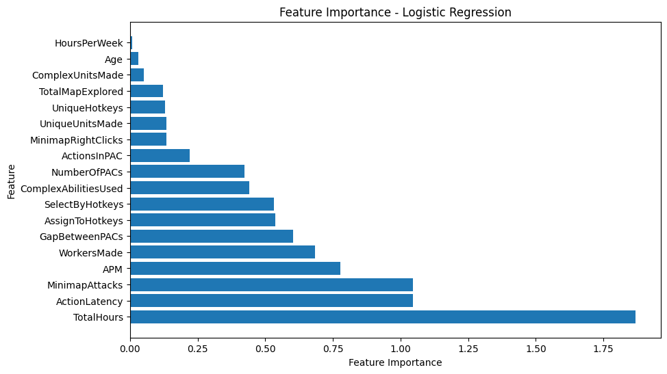

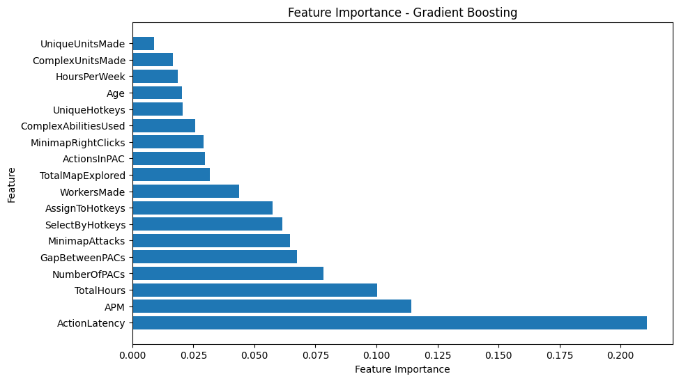

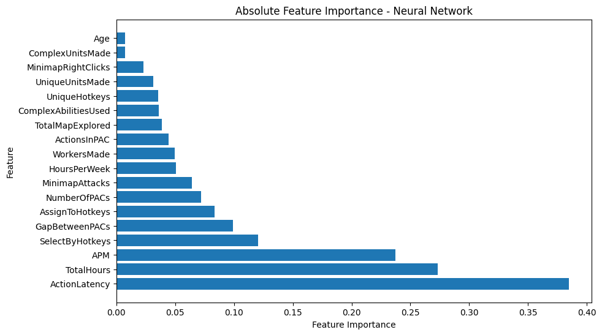

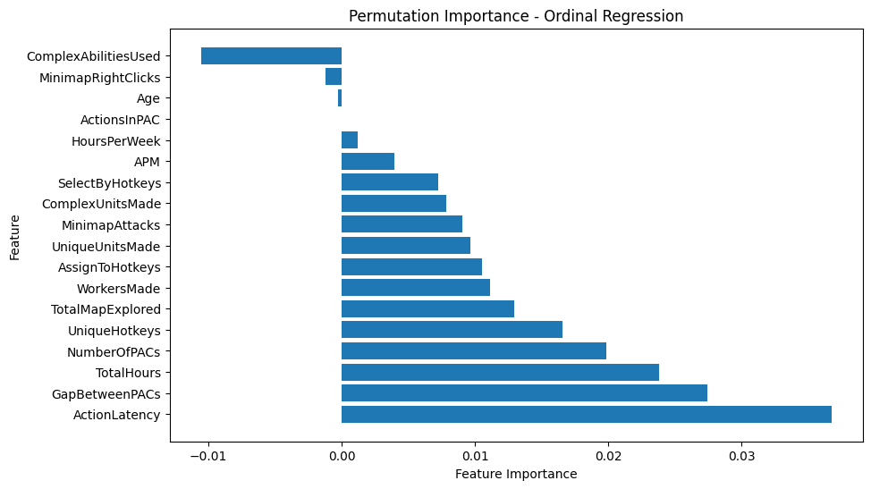

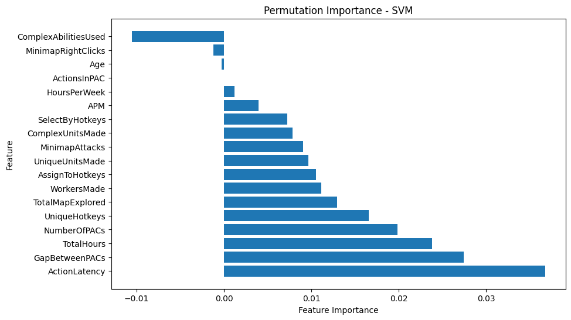

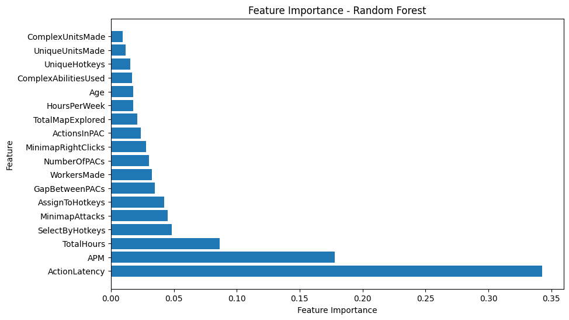

```python
# Plotting Feature importances of each model
plot_feature_importance(feature_names, abs_coefficients_lr, 'Feature Importance - Logistic Regression')
plot_feature_importance(feature_names, feature_importance_gradient, 'Feature Importance - Gradient Boosting')
plot_feature_importance(feature_names, feature_importance_neural, 'Absolute Feature Importance - Neural Network')
plot_feature_importance(feature_names, feature_importance_ord, 'Permutation Importance - Ordinal Regression')
plot_feature_importance(feature_names, feature_importance_svm, "Permutation Importance - SVM")
plot_feature_importance(feature_names, feature_importance_rf, 'Feature Importance - Random Forest')
```

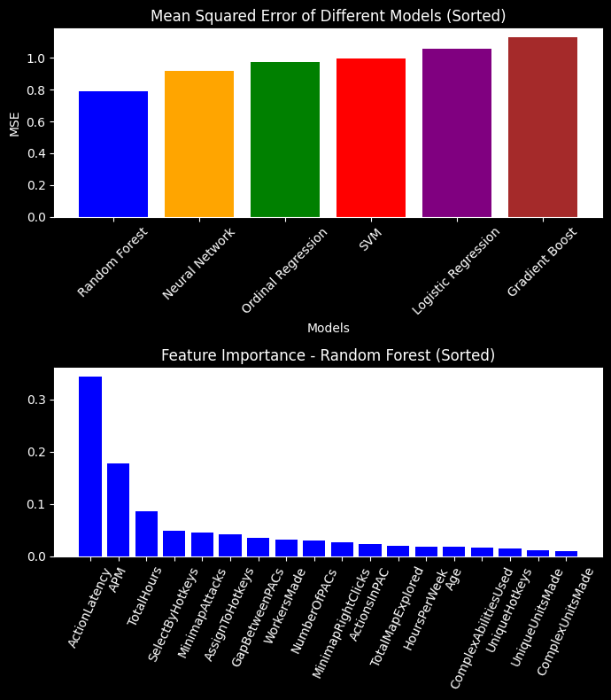

```python
# Sort the MSE values and the corresponding models
sorted_indices_mse = np.argsort(mse_values)[::1]  # from smallest to largest
mse_values = np.array(mse_values)[sorted_indices_mse].tolist()
models = np.array(models)[sorted_indices_mse].tolist()

# Sort the feature importance and the corresponding feature names
sorted_indices_rf = np.argsort(feature_importance_rf)[::-1]  # from largest to smallest
feature_importance_rf = np.array(feature_importance_rf)[sorted_indices_rf].tolist()
feature_names = np.array(feature_names)[sorted_indices_rf].tolist()

# Create a grid of subplots with adjusted height
fig, axes = plt.subplots(nrows=2, figsize=(7, 8))  # Adjust the height with figsize

# Change the background color of the figure to black
fig.set_facecolor('black')
for ax in axes:
    ax.tick_params(color='white', labelcolor='white')  # Change tick colors to white
    for spine in ax.spines.values():  # Change the spine colors to white
        spine.set_edgecolor('white')

# Plot the sorted MSE values in the first subplot
axes[0].bar(models, mse_values, color=colors)
axes[0].set_xlabel('Models', color='white')
axes[0].set_ylabel('MSE', color='white')
axes[0].set_title('Mean Squared Error of Different Models (Sorted)', color='white')
axes[0].set_xticks(models)
axes[0].set_xticklabels(models, rotation=45, color='white')

# Plot the sorted feature importance for Random Forest in the second subplot
axes[1].bar(feature_names, feature_importance_rf, color='blue')  # Adjust bar color to white or other suitable color
axes[1].set_title('Feature Importance - Random Forest (Sorted)', color='white')
axes[1].set_xticks(feature_names)
axes[1].set_xticklabels(feature_names, rotation=65, color='white')

# Adjust the space between the plots
plt.subplots_adjust(hspace=0.5)

# Tight layout
plt.tight_layout()

# Save the combined figure
plt.savefig('sorted_mse_and_rf_importance.png', facecolor='black')

# Show the plots
plt.show()
```

### From above graphs, Action Latency, Total hours, and APM were a majority of the models most important features.

```python
#Showing the most important features of the best model (RF)
# Sort features by importance
feature_indices = np.argsort(np.abs(feature_importance_rf))[::-1]
sorted_features = feature_names[feature_indices]
sorted_importances = feature_importance_rf[feature_indices]

# Display the top 5 most important features
top_features = sorted(zip(sorted_features[:5], sorted_importances[:5]), key=lambda x: x[1], reverse=True)
for feature, importance in top_features:
    print(f"Feature: {feature}, Importance: {importance}")
```

```
Feature: ActionLatency, Importance: 0.342695211003904
Feature: APM, Importance: 0.17777432065163282
Feature: TotalHours, Importance: 0.08627322869733454
Feature: SelectByHotkeys, Importance: 0.04825817773456356
Feature: MinimapAttacks, Importance: 0.04490580633337749
```